# Checkpoint 3

# Libraries

```r
library(dplyr)
```

```r
library(usmap)
library(maps)
library(ggplot2)
library(tidyverse)
library(ggmap)
library(viridis)
library(rgdal)
require(janitor)
require(reshape2)
require(tidyr)
require(rstan)
require(rstanarm)
require(bayesplot)
```

# Data

```r
Finaldata<- read.csv("FinalDataSet.csv")
```

Re-Cleaned

```r
Finaldata <- Finaldata %>% select(-c(X,X.1)) %>%
  mutate(Region = ifelse(State %in% c("AK","CA","OR","WA","HI"), "West", ifelse(State %in% c("CO","UT","ID","MT","WY", "NM", "AZ", "NV"), "Mountain", ifelse(State %in% c("SD","ND","MN","KS","IN", "MI", "NE", "IA", "WI","IL", "OH", "MO", "OK"), "Midwest",  ifelse(State %in% c("TX","AL","MS","FL","AR", "WV", "TN", "NC", "SC","GA", "VA", "KY", "LA"), "South", ifelse(State %in% c("MD","PA","DE","NJ","NY", "MA", "CT", "NH", "VT","ME", "RI", "DC"), "Northeast", 0))))))
```

## Dataset Description

`Demographic:` Our dataset, `Demographic`, was created by merging three other datasets which all contained different demographic and election information. We obtained the main portion of our demographic data from the US Census Bureau’s American Community Survey (ACS) which is an ongoing survey administered by the U.S. Census Bureau. It gathers information on income, employment, housing characteristics, etc, annually for all the 50 U.S. States on the county and state level. To access the county-level dataset we used the R package called Choroplethr which provides API connections to data sources like the ACS. The ACS County-Level dataset was then merged with a county-level election outcome dataset that was created by Tony McGoven. Tony’s dataset contained presidential election results for 2008,2012, and 2016 but we chose to focus solely on the most recent election,2016. That said, the 2016 election results at the county-level were scraped from results published by Townhall.com. However, the State of Alaska reports results at the precinct or state level so there was no county-level data available. Therefore, another dataset had to be created that contained the election results for Alaska and this was done using the official election results provided by the Alaska Division of Elections and was later merged in. The final dataset that was used came from Alicia Johnson and it contained information on a state’s political leaning. Meaning it categorizes each county as belonging to a blue/red/purple state based on the state categorizations at 279towin.

## Dataset Details

```r
dim(Finaldata)
```

```
## [1] 765  32
```

```r
names(Finaldata)
```

```
##  [1] "polyname"                "State"
##  [3] "StateColor"              "total_2016"
##  [5] "dem_2016"                "gop_2016"
##  [7] "oth_2016"                "total_population"
##  [9] "percent_white"           "percent_black"
## [11] "percent_asian"           "percent_hispanic"
## [13] "per_capita_income"       "median_rent"
## [15] "median_age"              "percent_democrat2016"
## [17] "percent_republican2016"  "percent_other2016"
## [19] "Winner"                  "date"
## [21] "positive"                "negative"
## [23] "death"                   "hospitalized"
## [25] "totalTestResults"        "FIPS"
## [27] "StayAtHome_date"         "Quarantine_Yes"
## [29] "na.rm"                   "mean_ChinaVirusInterest"
## [31] "mean_KungFluInterest"    "Region"
```

```r
head(Finaldata)
```

```
##   polyname State StateColor total_2016 dem_2016 gop_2016 oth_2016
## 1  alabama    AL        red    2078165   718084  1306925    53156
## 2  alabama    AL        red    2078165   718084  1306925    53156
## 3  alabama    AL        red    2078165   718084  1306925    53156
## 4  alabama    AL        red    2078165   718084  1306925    53156
## 5  alabama    AL        red    2078165   718084  1306925    53156
## 6  alabama    AL        red    2078165   718084  1306925    53156
##   total_population percent_white percent_black percent_asian
## 1          4799277          0.67          0.26          0.01
## 2          4799277          0.67          0.26          0.01
## 3          4799277          0.67          0.26          0.01
## 4          4799277          0.67          0.26          0.01
## 5          4799277          0.67          0.26          0.01
## 6          4799277          0.67          0.26          0.01
##   percent_hispanic per_capita_income median_rent median_age
```

[output cut: 34 more lines]

```r
summary(Finaldata)
```

```
##        polyname       State      StateColor    total_2016
##  alabama   : 15   AK     : 15   blue  :285   Min.   : 248742
##  alaska    : 15   AL     : 15   purple:165   1st Qu.: 730628
##  arizona   : 15   AR     : 15   red   :315   Median :1922218
##  arkansas  : 15   AZ     : 15                Mean   :2489256
##  california: 15   CA     : 15                3rd Qu.:3208899
##  colorado  : 15   CO     : 15                Max.   :9631972
##  (Other)   :675   (Other):675
##     dem_2016          gop_2016          oth_2016      total_population
##  Min.   :  55949   Min.   :  11553   Min.   :  8496   Min.   :  570134
##  1st Qu.: 266827   1st Qu.: 345598   1st Qu.: 38767   1st Qu.: 1583364
##  Median : 779535   Median : 947934   Median : 91364   Median : 4361333
##  Mean   :1188393   Mean   :1179254   Mean   :121608   Mean   : 6108975
##  3rd Qu.:1534487   3rd Qu.:1535513   3rd Qu.:183694   3rd Qu.: 6819579
##  Max.   :5931283   Max.   :4681590   Max.   :515968   Max.   :37659181
##
##  percent_white    percent_black    percent_asian     percent_hispanic
##  Min.   :0.2300   Min.   :0.0000   Min.   :0.01000   Min.   :0.0100
##  1st Qu.:0.5900   1st Qu.:0.0300   1st Qu.:0.01000   1st Qu.:0.0400
##  Median :0.7400   Median :0.0700   Median :0.02000   Median :0.0800
##  Mean   :0.7029   Mean   :0.1084   Mean   :0.03765   Mean   :0.1082
##  3rd Qu.:0.8300   3rd Qu.:0.1500   3rd Qu.:0.04000   3rd Qu.:0.1300
##  Max.   :0.9400   Max.   :0.4900   Max.   :0.37000   Max.   :0.4700
##
##  per_capita_income  median_rent       median_age    percent_democrat2016
##  Min.   :20618     Min.   : 448.0   Min.   :29.60   Min.   :0.2249
##  1st Qu.:24635     1st Qu.: 564.0   1st Qu.:36.30   1st Qu.:0.3609
##  Median :26824     Median : 658.0   Median :37.60   Median :0.4670
##  Mean   :28098     Mean   : 714.3   Mean   :37.66   Mean   :0.4501
##  3rd Qu.:30469     3rd Qu.: 838.0   3rd Qu.:39.00   3rd Qu.:0.5335
##  Max.   :45290     Max.   :1220.0   Max.   :43.20   Max.   :0.9285
##                    NA's   :15
##  percent_republican2016 percent_other2016        Winner           date
##  Min.   :0.04122        Min.   :0.01937   Democrat  :315   3/10/2020: 51
##  1st Qu.:0.41161        1st Qu.:0.04160   Republican:450   3/11/2020: 51
##  Median :0.49064        Median :0.05071                    3/12/2020: 51
##  Mean   :0.49010        Mean   :0.05976                    3/13/2020: 51
##  3rd Qu.:0.58095        3rd Qu.:0.06991                    3/14/2020: 51
##  Max.   :0.70052        Max.   :0.25598                    3/15/2020: 51
##                                                            (Other)  :459
```

[output cut: 17 more lines]

```
##  Mode:logical   Min.   :17.80           Min.   : 0.000
##  TRUE:750       1st Qu.:30.87           1st Qu.: 2.600
##  NA's:15        Median :37.47           Median : 3.600
##                 Mean   :37.24           Mean   : 3.903
##                 3rd Qu.:41.80           3rd Qu.: 4.600
##                 Max.   :52.40           Max.   :13.200
##
##     Region
##  Length:765
##  Class :character
##  Mode  :character
##
##
##
##
```

```r
colnames(Finaldata)
```

```
##  [1] "polyname"                "State"
##  [3] "StateColor"              "total_2016"
##  [5] "dem_2016"                "gop_2016"
##  [7] "oth_2016"                "total_population"
##  [9] "percent_white"           "percent_black"
## [11] "percent_asian"           "percent_hispanic"
## [13] "per_capita_income"       "median_rent"
## [15] "median_age"              "percent_democrat2016"
## [17] "percent_republican2016"  "percent_other2016"
## [19] "Winner"                  "date"
## [21] "positive"                "negative"
## [23] "death"                   "hospitalized"
## [25] "totalTestResults"        "FIPS"
## [27] "StayAtHome_date"         "Quarantine_Yes"
## [29] "na.rm"                   "mean_ChinaVirusInterest"
## [31] "mean_KungFluInterest"    "Region"
```

## Variables of Interest

| Variables: | Meaning: |
| --- | --- |
| `polyname` | State Name |
| `StateColor` | Political Leaning |
| `percent_hispanic` | Percent of the Population that is Hispanic |
| `percent_white` | Percent of the Population that is White |
| `percent_asian` | Percent of the Population that is Asian |
| `percent_black` | Percent of Population that is Black |
| `total_population` | Total State Population |
| `per_capita_income` | Income per Capita |
| `percent_democrat2016` | Percent of votes won by Democrat (Clinton) |
| `percent_republican2016` | Percent of votes won by Republican (Trump) |
| `Winner` | Indicator for whether a Republican or Democrat Won |
| `total_2016` | Total Number of Votes |

## Visualizations

### Demographic

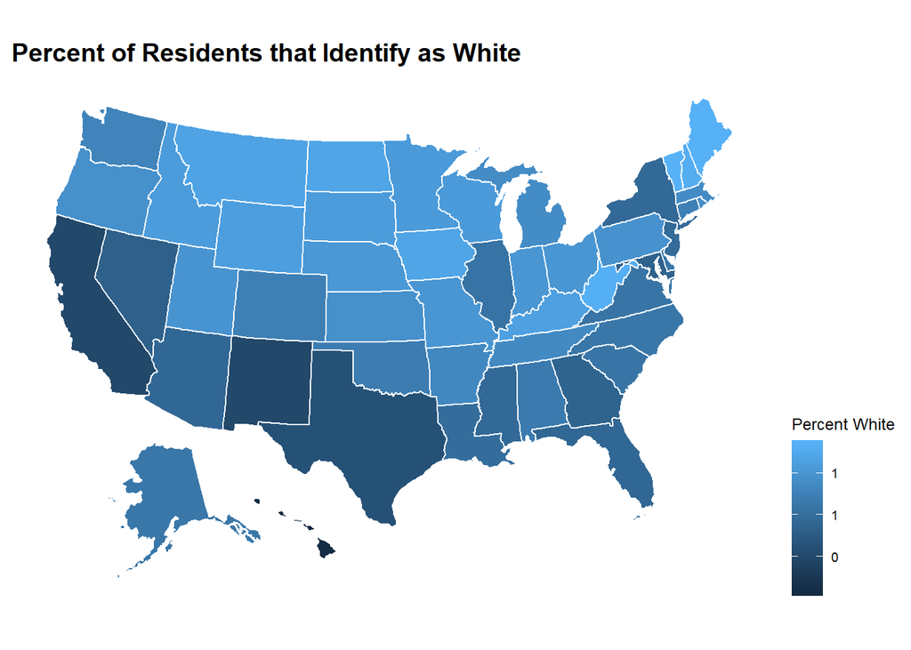

```r
#Demographic: Identification
Finaldata <- data.frame(Finaldata) %>% mutate(state = State)
plot_usmap(data = Finaldata, values = "percent_white", color = "white") +
  scale_fill_continuous(name = "Percent White", label = scales::comma) +
  theme(legend.position = "right")+ ggtitle("Percent of Residents that Identify as White") +
  theme(
plot.title = element_text(color="Black", size=14, face="bold")
)
```

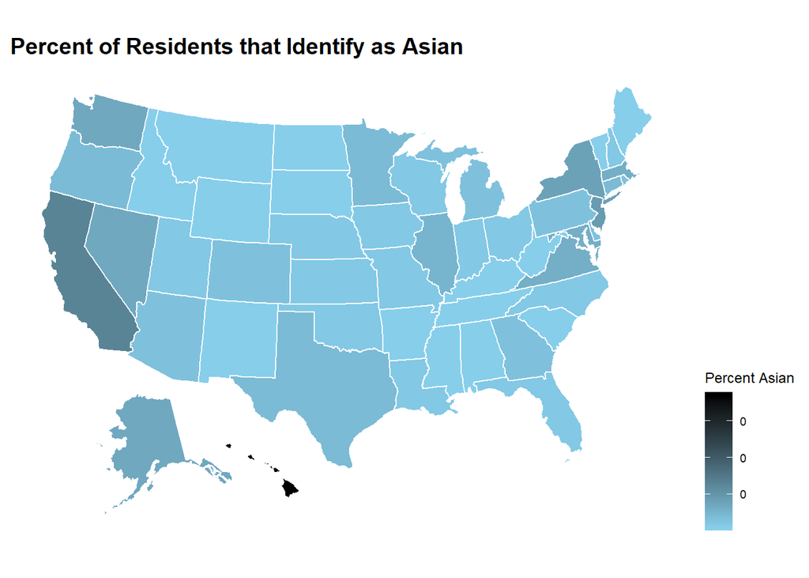

```r
plot_usmap(data = Finaldata, values = "percent_asian", color = "white") +
  scale_fill_continuous(low = "sky blue", high = "black", name = "Percent Asian", label = scales::comma) +
  theme(legend.position = "right") + ggtitle("Percent of Residents that Identify as Asian") +
  theme(
plot.title = element_text(color="Black", size=14, face="bold")
)
```

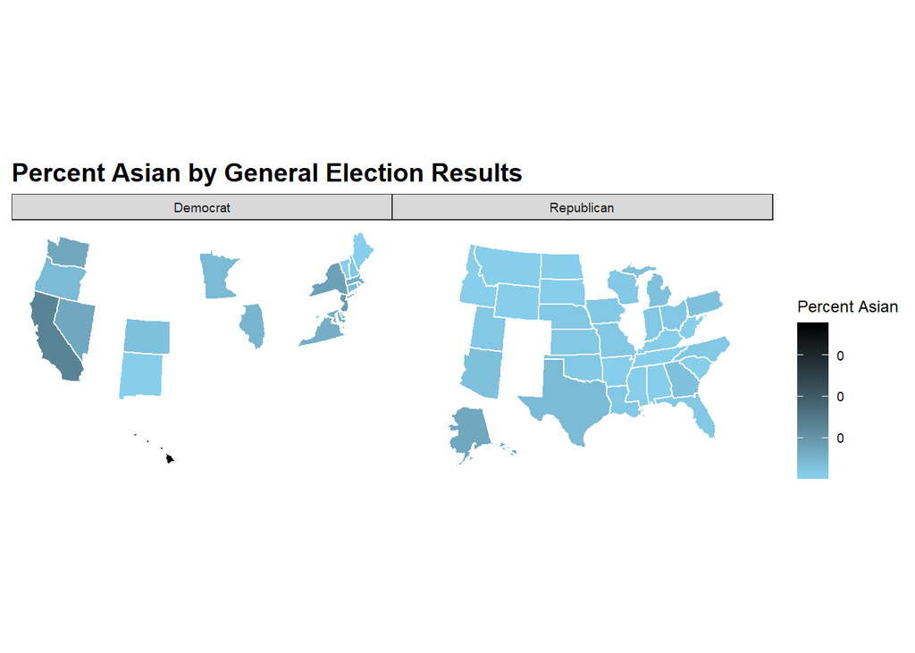

```r
#By Results
plot_usmap(data = Finaldata, values = "percent_asian", color = "white") +
  scale_fill_continuous(low = "sky blue", high = "black", name = "Percent Asian", label = scales::comma) +
  theme(legend.position = "right") + ggtitle("Percent Asian by General Election Results")+
  theme(
plot.title = element_text(color="Black", size=14, face="bold")
) + facet_wrap(~Winner)
```

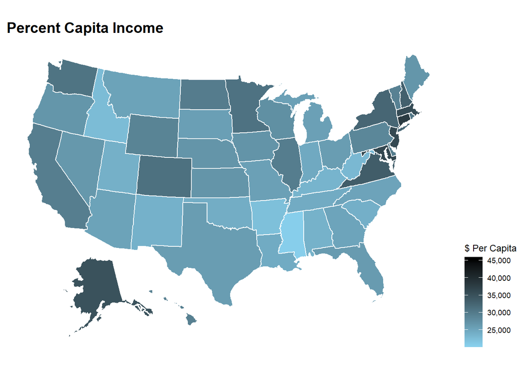

```r
#By income
plot_usmap(data = Finaldata, values = "per_capita_income", color = "white") +
  scale_fill_continuous(low = "sky blue", high = "black", name = "$ Per Capita", label = scales::comma) +
  theme(legend.position = "right") + ggtitle("Percent Capita Income")+
  theme(
plot.title = element_text(color="Black", size=14, face="bold")
)
```

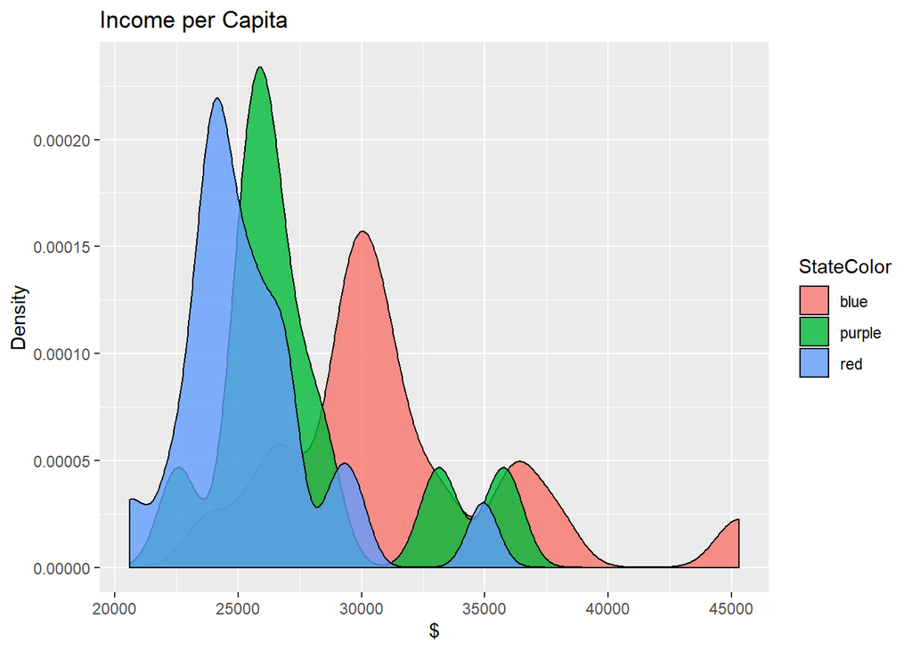

```r
#Income by state affiliation
ggplot(Finaldata, aes(x = per_capita_income, fill = StateColor)) +
    geom_density(alpha = .8)+ ggtitle("Income per Capita") + xlab("$") + ylab("Density")
```

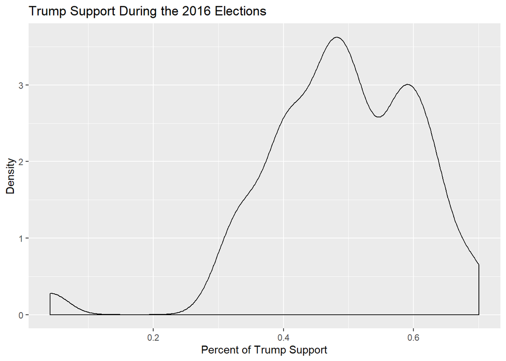

```r
#Trump Support
ggplot(Finaldata, aes(x = percent_republican2016)) +
    geom_density()+ ggtitle("Trump Support During the 2016 Elections") + xlab("Percent of Trump Support") + ylab("Density")
```

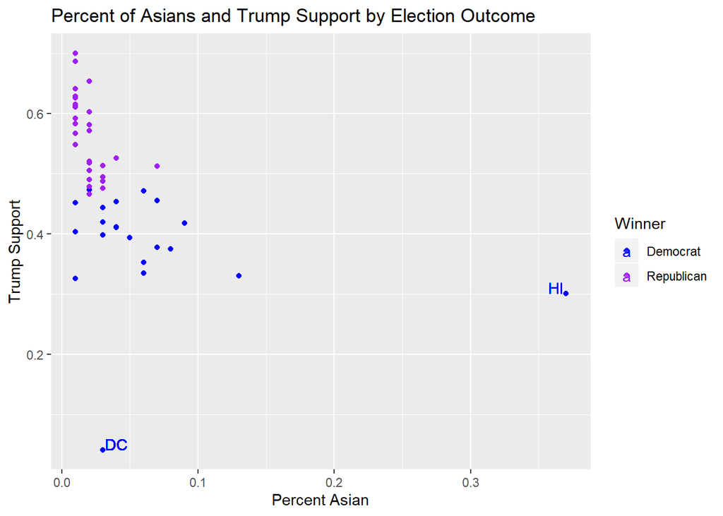

```r
ggplot(Finaldata, aes(x = percent_asian, y = percent_republican2016, color = Winner)) +
    scale_color_manual(values = c("blue","purple","red")) +
    geom_point(alpha = 0.8) + geom_text(aes(label=ifelse(percent_asian>.2,as.character(state),"")),hjust=1.2,vjust=0)+ geom_text(aes(label=ifelse(percent_republican2016<.2,as.character(state),"")),hjust=-.1,vjust=0) + ggtitle("Percent of Asians and Trump Support by Election Outcome") + xlab("Percent Asian") + ylab("Trump Support")
```

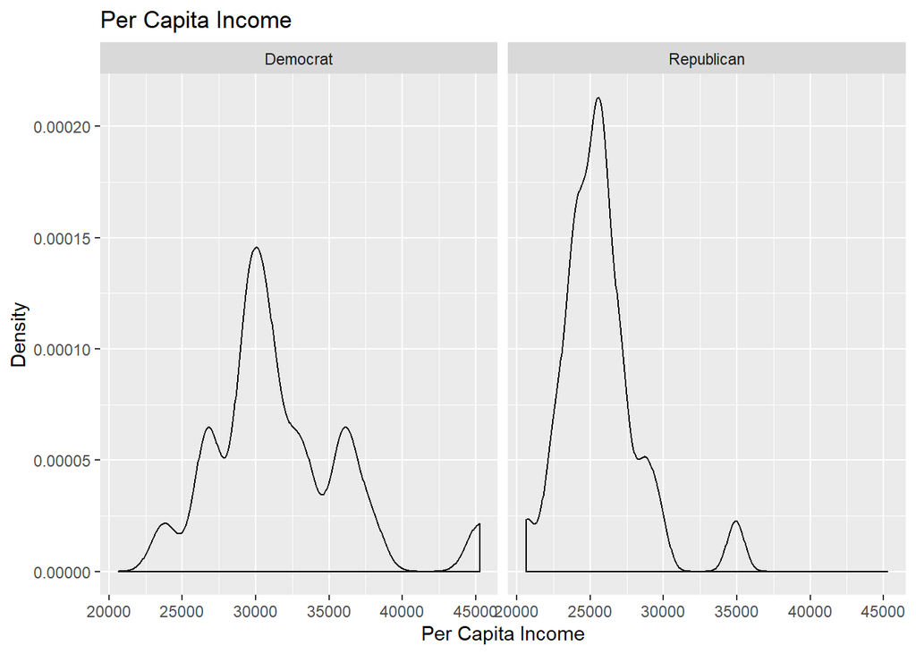

```r
ggplot(Finaldata, aes(x = per_capita_income)) +
    geom_density()+ ggtitle("Per Capita Income") + xlab("Per Capita Income") + ylab("Density") + facet_wrap(~Winner)
```

# Analysis